## ## YAML

```r
library(tidyverse)
library(datasauRus)
```

**1. Based on the help file, how many rows and how many columns does the `datasaurus_dozen` file have? What are the variables included in the data frame? (this can be hardcoded)**

A data frame with 1846 rows and 3 columns. The variables included are; a. dataset indicating which dataset the data are from b. x: x-values c. y: y-values

```r
datasaurus_dozen %>%
  count(dataset)
```

```r
library(tidyverse)
library(datasauRus)
```

**1. Based on the help file, how many rows and how many columns does the `datasaurus_dozen` file have? What are the variables included in the data frame? (this can be hardcoded)** A data frame with 1846 rows and 3 columns. The variables included are; a. dataset indicating which dataset the data are from b. x: x-values c. y: y-values

```r
datasaurus_dozen %>%
  count(dataset)
```

```
## # A tibble: 13 × 2
##    dataset        n
##    <chr>      <int>
##  1 away         142
##  2 bullseye     142
##  3 circle       142
##  4 dino         142
##  5 dots         142
##  6 h_lines      142
##  7 high_lines   142
##  8 slant_down   142
##  9 slant_up     142
## 10 star         142
## 11 v_lines      142
## 12 wide_lines   142
## 13 x_shape      142
```

## Data visualization and summary

**2. Plot `y` vs. `x` for the `dino` dataset. Then, calculate the correlation coefficient between `x` and `y` for this dataset.**

```r
dino_data <- datasaurus_dozen %>%
  filter(dataset == "dino")
```

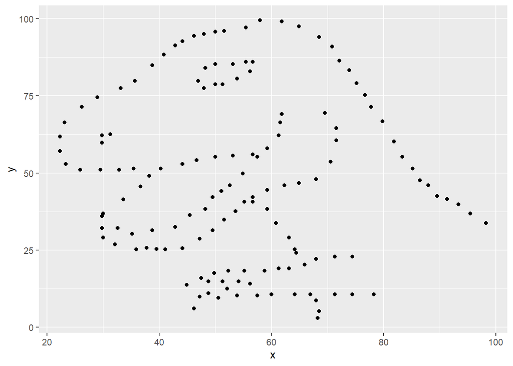

```r
ggplot(data = dino_data, mapping = aes(x = x, y = y)) +
  geom_point()
```

```r
dino_data %>%
  summarize(r = cor(x, y))
```

[output not shown]

```r
dino_data <- datasaurus_dozen %>%
  filter(dataset == "dino")
```

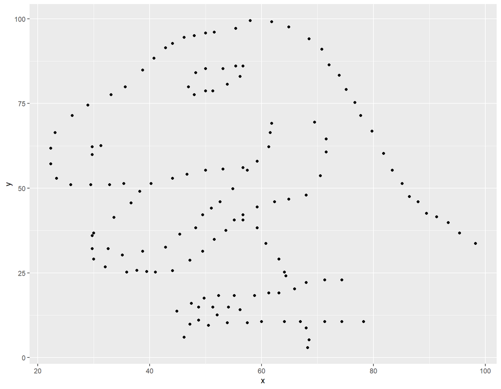

```r
ggplot(data = dino_data, mapping = aes(x = x, y = y)) +
  geom_point()
```

```r
dino_data %>%
  summarize(r = cor(x, y))
```

[output not shown]

**3. Plot `y` vs. `x` for the `star` dataset. You can (and should) reuse code we introduced above, just replace the dataset name with the desired dataset. Then, calculate the correlation coefficient between `x` and `y` for this dataset. How does this value compare to the `r` of `dino`?**

```r
datasaurus_dozen %>%
  count(dataset)
```

```r
datasaurus_dozen %>%
  count(dataset)
```

```
## # A tibble: 13 × 2
##    dataset        n
##    <chr>      <int>
##  1 away         142
##  2 bullseye     142
##  3 circle       142
##  4 dino         142
##  5 dots         142
##  6 h_lines      142
##  7 high_lines   142
##  8 slant_down   142
##  9 slant_up     142
## 10 star         142
## 11 v_lines      142
## 12 wide_lines   142
## 13 x_shape      142
```

```r
star_data <- datasaurus_dozen %>%
  filter(dataset == "star")
```

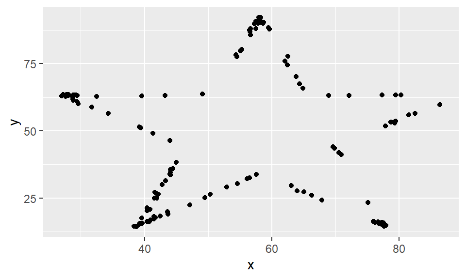

```r
ggplot(data = star_data, mapping = aes(x = x, y = y)) +
  geom_point()
```

```r
star_data %>%
  summarize(r = cor(x, y))
```

[output not shown]

The r of “dino” is -0.06447185 while the r of “star” is -0.0629611 . The value of r of star is identical to r of dino in that for the both structures, there is a very weak inverse linear relationship between the variables x and y for both datasets. The correlation values does not entirely indicate that they are of different structures because the values are both negative, nearly the same and so close to zero (0). This would mean that the degree of linear relationship between x and y in both the dino and star dataset is almost identical.

```r
star_data <- datasaurus_dozen %>%
  filter(dataset == "star")
```

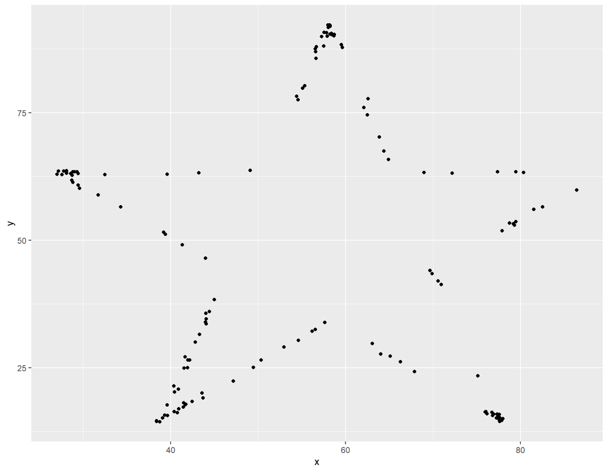

```r
ggplot(data = star_data, mapping = aes(x = x, y = y)) +
  geom_point()
```

```r
star_data %>%
  summarize(r = cor(x, y))
```

[output not shown]

**4. Plot `y` vs. `x` for the `circle` dataset. You can (and should) reuse code we introduced above, just replace the dataset name with the desired dataset. Then, calculate the correlation coefficient between `x` and `y` for this dataset. How does this value compare to the `r` of `dino`?**

```r
datasaurus_dozen %>%
  count(dataset)
```

```r
datasaurus_dozen %>%
  count(dataset)
```

```
## # A tibble: 13 × 2
##    dataset        n
##    <chr>      <int>
##  1 away         142
##  2 bullseye     142
##  3 circle       142
##  4 dino         142
##  5 dots         142
##  6 h_lines      142
##  7 high_lines   142
##  8 slant_down   142
##  9 slant_up     142
## 10 star         142
## 11 v_lines      142
## 12 wide_lines   142
## 13 x_shape      142
```

```r
circle_data <- datasaurus_dozen %>%
  filter(dataset == "circle")
```

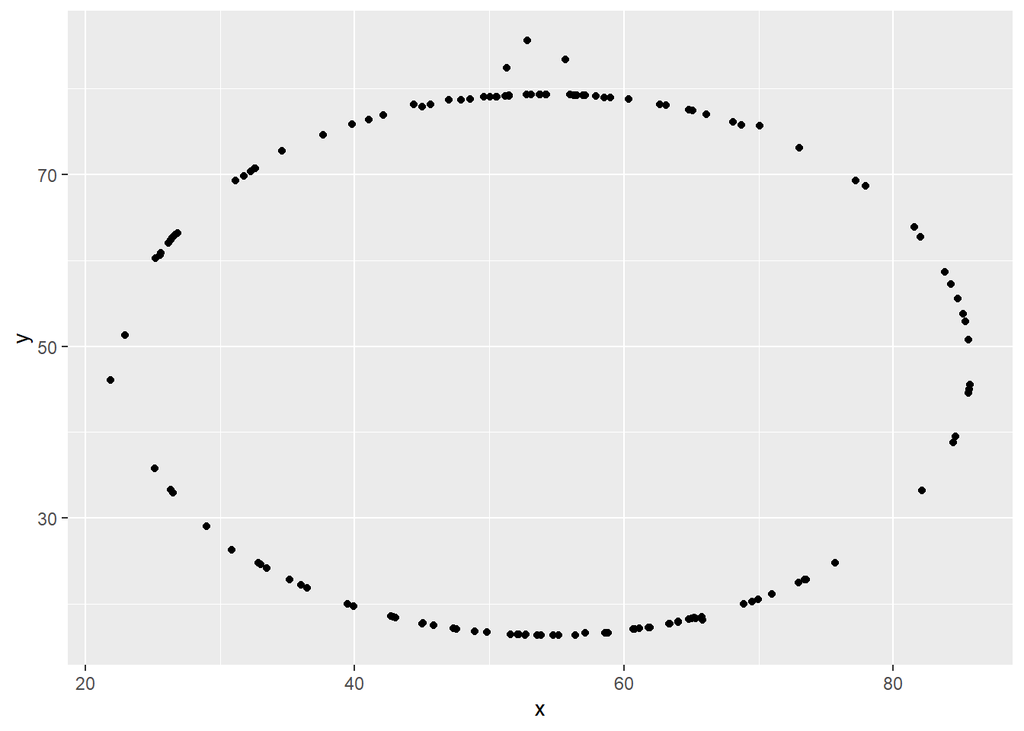

```r
ggplot(data = circle_data, mapping = aes(x = x, y = y)) +
  geom_point()
```

```r
circle_data %>%
  summarize(r = cor(x, y))
```

[output not shown]

The r of “dino” is -0.06447185 while the r of “circle” is -0.06834336. For both datasets, the correlation coefficient are very close. The negative values which are close to zero (0) for both datasets indicates a very weak inverse linear relationship between the variables x and y for each dataset. Though the correlation coefficients are nearly similar, the visuals generated are different. Hence correlation does not sufficiently describe a data.